# R for Marine Science - Workshop 1

Author

Rebecca Castellaro

## Dataset summary

This workshop used the Palmer Penguins dataset, a real morphological and environmental dataset collected across three islands in the Palmer Archipelago, Antarctica, covering three penguin species: Adelie, Chinstrap, and Gentoo. The dataset includes physical measurements (bill length, bill depth, flipper length, body mass) alongside categorical variables such as species, island, and sex, recorded for several hundred individual penguins. It was used here to practice core data wrangling, including cleaning, filtering, sorting, and aggregating a real biological dataset, and to compare body mass patterns across species, islands, and sexes.

## Methods

Before any analysis, the dataset was inspected using `glimpse()` and `str()` to check variable types and identify columns containing missing values. The core dplyr verbs `select()`, `filter()`, `arrange()`, and `mutate()` were used to practice isolating variables of interest, subsetting records by condition, sorting by body mass, and computing new variables such as bill length to bill depth ratio. A comparison between a legacy `data.frame` and a modern tibble was also carried out directly on this dataset to observe their different console behaviours before moving into aggregation with `group_by()` and `summarise()`.

## Body mass by species and island

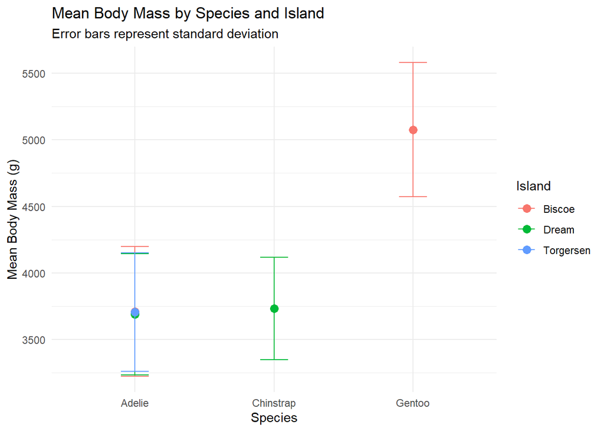